# User’s Manual

## Centrality table

[figure not shown]

The centrality table tab has exactly the same functions as the centrality plot tab. For more information on the different centrality measures and functions, you can read the centrality plot section

### Download Centrality Table

After chosing the centrality measures, the centrality table can be downloaded as a .txt file.

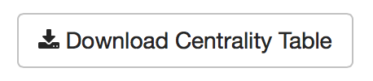

# Clustering Analyses

Besides centrality measures, *Clustering coefficients* can be interesting for the assessment of a network. The local lustering coefficient of a node is the ratio of amount of connections of a specific node, and the maximum possible amount of connections (Costantini et al. 2015). The clustering coefficient can give information on the importance of a node in a network: if a node’s neighbours are already connected to each other, removing that initial node will not result in drastic changes.

Often, clustering coefficients are calculated by looking at the amount of *triangles* that a specific node is part of: three nodes that are connected to each other. Note that clustering coefficients can only be calculated for undirected networks. In the application, if the user constructed a directed network, clustering coefficients are automatically computed for the undirected version.

## Clustering Plot

### Standardized Clustering Coefficients

Clustering measures are by default standardized, but you can uncheck this option in order to obtain the raw clustering measures.

### WS

The *WS* (Watts & Strogatz) is the unweighted clustering coefficient of a specific node. As its definition states, the edge weights are not taken into account in the calculation of the clustering coefficients.

### Zhang

The *Zhang* clustering coefficient is a clustering coefficient for weighted networks. It is similar to the WS coefficient, but instead of looking at the maximum amount of connections that a node may have, the Zhang coefficient looks at the maximum possible value that can be obtained with the edge weights.

### Onnela

The *Onnela* clustering coefficients calculates a clustering coefficient for each node by taking into account the edge weights that exist in the triangles, and the amount of triangles that a specific node is part of. The Onnela coefficient differs from the Barrat coefficient in that the Onnela coefficient scales the edge weights into the *average intensity*.

### Barrat

The *Barrat* clustering coefficient calculates a coefficient for each node by taking into account the edge weights that exist in the triangles, and the amount of triangles that a specific node is part of.

### Download Clustering Plot

After chosing the clustering coefficients and deciding on the plot layout, the clustering plot can be downloaded as a .pdf file.

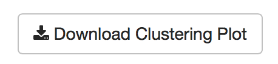

## Clustering Table

The clustering table tab has exactly the same functions as the clustering plot tab. For more information on the different clustering coefficients and functions, you can read the clustering plot section

### Download Clustering Table

After chosing the clustering coefficients, the clustering table can be downloaded as a .txt file.

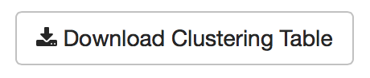

# Network Comparison

It may be interesting for some researchers to investigate the difference between two network structures. This has now been made possible in the application (Van Borkulo et al. 2015). The *Network Comparison Test* works independently of the rest of the application. Note that the grey left panel is not needed for the Network Comparison test.

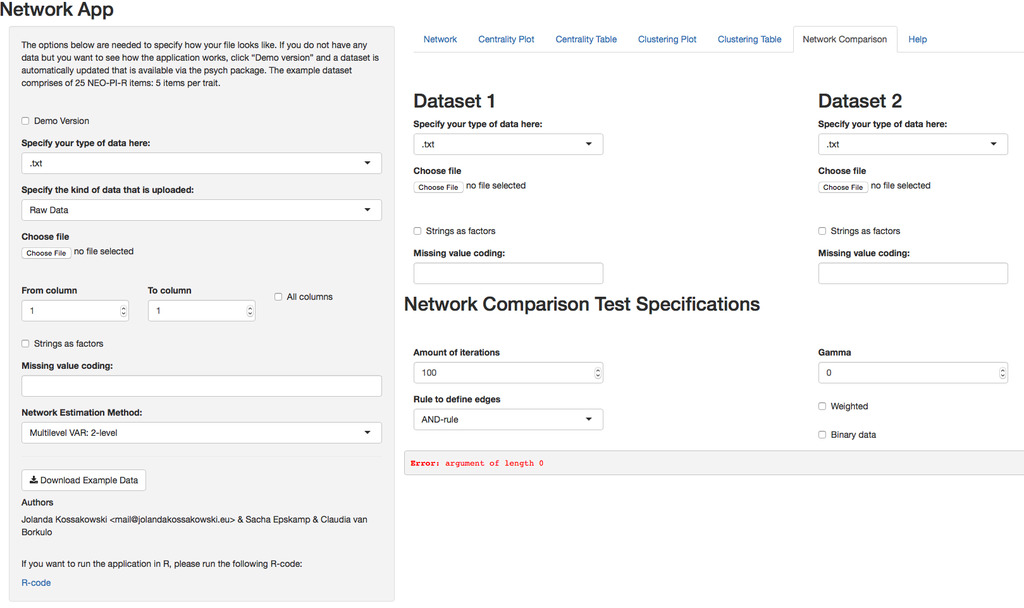

The difference between network structures is defined as the deviation in absolute weighted sum scores of the connections (Barrat et al. 2004). This permutation-based test randomly regroups participants from both samples repeatedly and calculates the differences between these subsamples. The resulting distribution under the null hypothesis (both subsamples are equal) is used to test the observed difference of the original subsamples (Kossakowski et al. 2015).

The result of the comparison test is expressed as a *p*-value, which can then be set off against an alpha of your choosing

## Uploading Data

As with the construction of a network, the two samples need to be uploaded. Note that ONLY raw data can be used in this comparison test. Please read the data uploading section for more information.

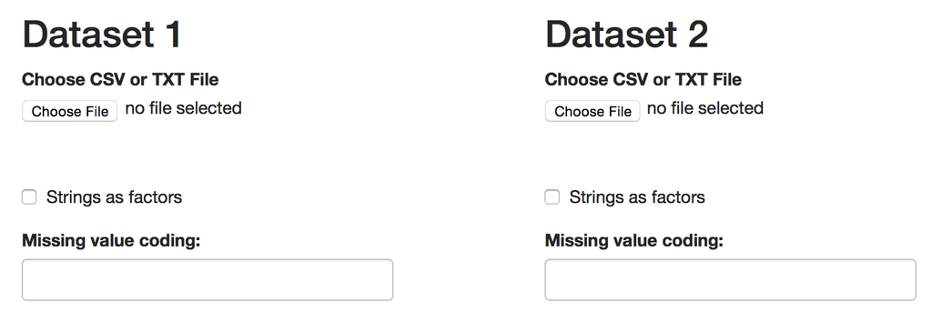

## Specifications

After uploading the data, the user can set a few specifications before running the comparison test.

### Iterations

The user can specify how many iterations are appropriate for the comparison. The default is 100 iterations, but the standard is 1000 iterations. Note that, the higher the amount of iterations, the longer it takes for the test to be finished.

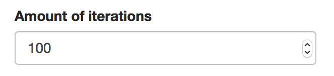

### Gamma

The *gamma* is the tuning parameter that is needed for the Extended Bayesian Information Criterion (EBIC) that is used within the function. The default is 0, but 0.5 is also often chosen.

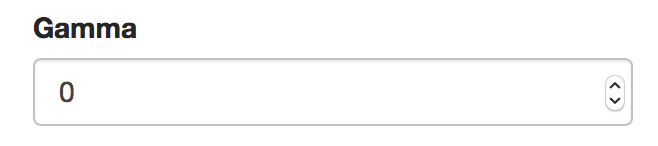

### Edge defining rule

The Network Comparison Test fit an Ising network to the data before calculating the difference between the networks. The result of this fitting procedure is an asymmetrical adjacency matrix, where a nonzero value stands for the presence of an edge.

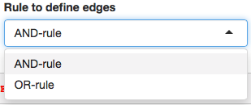

In order to fit an Ising network, the user must specify what kind of rule must be used to define the absence or presence of an edge. The *AND-rule* states that in the adjacency matrix, both the edge from node 1 to node 2 and the edge from node 2 to node 1 must be nonzero in order for that edge to be drawn. The resulting edge is the average of the two edge weights:

```
##      [,1] [,2]
## [1,]  0.0  0.3
## [2,]  0.6  0.0
```

```
## [1] 0.45
```

In this example, an edge weight frome node 1 to node 2 and an edge weight from node 2 to node 1 is returned by the IsingFit function, and thus in the resulting network, an edge is drawn with it weight being the average of the two edge weights.

```
##      [,1] [,2]
## [1,]  0.0    0
## [2,]  0.6    0
```

```
## [1] 0
```

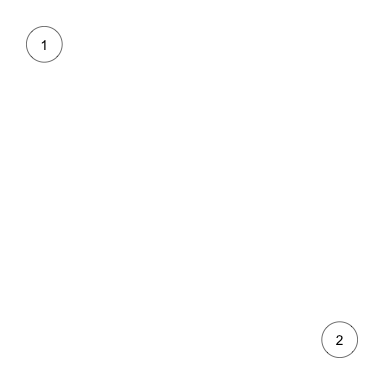

Here, only an edge from node 2 to node 1 is returned by the IsingFit function, and as a result, no edge is drawn between the two nodes.

When the *OR-rule* is used, at least of the two possible edges between nodes 1 and 2 (from node 1 to node 2 or from node 2 to node 1) needs to be nonzero it order for it to be drawn. When only one of the two edges is nonzero, that value is used as the edge weight. In the case that both entries are nonzero, the average is used as the edge weight:

```
##      [,1] [,2]
## [1,]  0.0    0
## [2,]  0.6    0
```

```
##      [,1] [,2]
## [1,]  0.0  0.3
## [2,]  0.6  0.0
```

```
## [1] 0.45
```

In these two cases, at least one edge is nonzero, and thus in the resulting network, an edge is drawn.

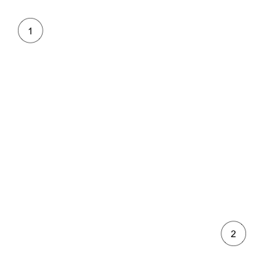

In this example, both the edge from node 1 to node 2 and the edge from node 2 to node 1 are zero, and thus no edge is drawn between the two nodes.

### Weighted Networks

Depending on the research question, the user can specify whether weighted networks are to be compared, or whether unweighted networks are used. Weighted networks take the edge weights into account, whereas unweighed networks only look at the absence/presence of an edge.

### Binary Data

References

Barrat, Alain, Marc Barthelemy, Romualdo Pastor-Satorras, and Alessandro Vespignani. 2004. “The Architecture of Complex Weighted Networks.” *Proceedings of the National Academy of Sciences of the United States of America* 101. National Acad Sciences: 3747–52.

Costantini, Giulio, Sacha Epskamp, Denny Borsboom, Marco Perugini, René Mõttus, Lourens J Waldorp, and Angélique OJ Cramer. 2015. “State of the ARt Personality Research: A Tutorial on Network Analysis of Personality Data in R.” *Journal of Research in Personality* 54. Elsevier: 13–29.

Csardi, Gabor, and Tamas Nepusz. 2006. “The Igraph Software Package for Complex Network Research.” *InterJournal, Complex Systems* 1695: 1–9. http://igraph.org.

Epskamp, Sacha, Angélique O. J. Cramer, Lourens J. Waldorp, Verena D. Schmittmann, and Denny Borsboom. 2012. “qgraph: Network Visualizations of Relationships in Psychometric Data.” *Journal of Statistical Software* 48: 1–18. http://www.jstatsoft.org/v48/i04/.

Fruchterman, Thomas M J, and Edward M Reingold. 1991. “Graph drawing by force-directed placement.” *Software: Practice and Experience* 21: 1129–64.

Kalisch, Markus, Martin Mächler, Diego Colombo, Marloes H Maathuis, and Peter Bühlmann. 2012. “Causal Inference Using Graphical Models with the R Package Pcalg.” *Journal of Statistical Software* 47 (11): 1–26.

Kossakowski, Jolanda J, Sacha Epskamp, Jacobien M Kieffer, Claudia D van Borkulo, Mijke Rhemtulla, and Denny Borsboom. 2015. “The Application of a Network Approach to Health-Related Quality of Life (HRQoL): Introducing a New Method for Assessing HRQoL in Healthy Adults and Cancer Patient.”

Mõttus, R, S Epskamp, and A Francis. Submitted for Publication. “Within-Individual Variability of Personality Characteristics and Physical Exercise: Contemporaneous and Lagged Associations.” *Journal of Research in Personality*.

Pearl, Judea. 2009. *Causality*. Cambridge university press.

Van Borkulo, C D, L J Waldorp, L Boschloo, R A Schoevers, and D Borsboom. 2015. “Tatistical Comparison of Two Net- Works with Respect to Global Strength.” https:// github.com/cvborkulo/NetworkComparisonTest.

Watts, Duncan J, and Steven H Strogatz. 1998. “Collective Dynamics of ‘Small-World’ Networks.” *Nature* 393. Nature Publishing Group: 440–42.

Wild, Beate, Michael Eichler, Hans-Christoph Friederich, Mechthild Hartmann, Stephan Zipfel, and Wolfgang Herzog. 2010. “A Graphical Vector Autoregressive Modelling Approach to the Analysis of Electronic Diary Data.” *BMC Medical Research Methodology* 10: 1–13.

Zhao, Tuo, Han Liu, Kathryn Roeder, John Lafferty, and Larry Wasserman. 2014. *Huge: High-Dimensional Undirected Graph Estimation*. http://CRAN.R-project.org/package=huge.